# STA304H1F/1003HF Fall 2018 Assignment # 3

### 1)

#### (a)

Strata sample sizes are determined by the following equation :

- nh=(Nh/N)*n

where nh is the sample size for stratum h, Nh is the population size for stratum h, N is total population size, and n is total sample size.And the **nh=5** by caculated

I randomly selected 5 player in each team

#### (c)

The estimated proportion of players in the data set of stratified sample who are pitchers is 0.5466667,and the 95% CI is (0.4670007,0.6263326)

#### (d)

The *estimated proportion* of players in the data set of a simple random sample who are pitchers is 0.42,and the 95% CI is (0.3410156,0.4989844)

Compared with that of (c),the length of the CI in part (c) is 0.1593318,and the in part (d),the length of the CI is 0.1579687.The proportion in CI of simple random sample is smaller than in stratified sample; and the *estimated porportion* here is smaller than in part(c).

#### (e)

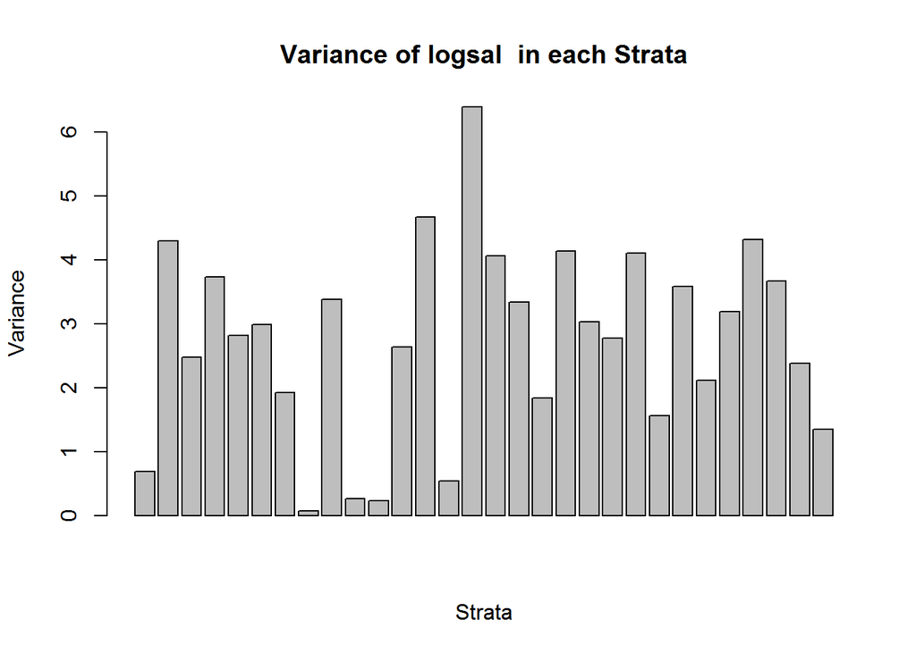

According to barplot, the difference in variance of *logsal* between each Strata is relatively large,that is ,the fluctuation of *logsal* in each Strata is relatively large.I think optimal allocation would be worthwhile for this problem.it can reduce the cost of Strata sampling beacuse of variance in Statum.

#### (f)

According tho the formule from the text book,we can get the estimated population stratum variance below.

The equation for Neyman allocation can be derived from the equation for optimal allocation by assuming that the direct cost to sample an individual element is equal across strata. Based on Neyman allocation, the best sample size for stratum h would be:

- nh=n*(Nh*sigma_h)/(sum(Ni*sigma_h))

where nh is the sample size for stratum h, n is total sample size, Nh is the population size for stratum h, and σh is the standard deviation of stratum h.

So,according to the result above,the estimate the proportional allocation population stratum variances is 0.0146508,and the sample size in each stratum respectively is :3, 7, 5, 6, 5, 5, 5, 1, 6, 2, 2, 5, 7, 2, 7, 6, 6, 5, 7, 5, 5, 6, 4, 6, 5, 6, 7, 6, 5, 4.The optimal allocation stratum variances is 0.0115837,we can know that ,the variance of allocation stratum variances is always smaller than proportional allocation population stratum variances otr equal.

### 2)

```
## 'data.frame':    251 obs. of  2 variables:
##  $ height  : num  158 178 165 165 173 160 190 180 170 178 ...
##  $ handspan: num  19 20.5 21 17.5 13 18 20.3 20.5 22 17 ...
```

#### (a)

```
## Parameter 0.1159228
## Variance Parameter 0
## Confidence Interval:  [ 0.1159228 ; 0.1159228 ]
```

```
## A SRS estimator  of the population mean handspan  is: 17.99
```

```
## A ratio estimator  of the population mean handspan  is: 19.3081
```

```
## A regression-based estimator  of the population mean handspan  is: 19.37006
```

#### (b)

```
## SSR error of estimator is : 1.736693
```

```
## Ratio error of estimator is : 0.4185967
```

```
## Regression error of estimator is: 0.3566356
```

We can know the error of estimation respectively,and the error of SSR is biggest,Ratio estimator’s secondly,and Regression’s is smallest.

#### (c)

```
## The variance of SSR estimator is : 9.158778
```

```
## The variance of Ratio estimator is : 1.015144
```

```
## The variance of regression-based estimator is : 0.4285674
```

### 3)

#### (b)

```
## The estimation of total number of boxes of cereal sold by all supermarkets in the area is : 2361.8
```

Yes,I have enough information to get the estimation.According to the equation:

- ```
   mu.sample/mu.total =n /M
  ```

So,the estimation can be caculated.